# Zadanie zaliczeniowe Statystyczna Analiza Danych 24/25L

Maksymilian Kulicki

2025-06-01

# 1. Eksploracja danych

Dane do zadania zostały pobrane ze strony: https://www.kaggle.com/competitions/sad-2024-25-lab-grupa-2/data?select=y_train.csv. Dane pochodzą z eksperymentu multimodalnego sekwencjonowania pojedynczych komórek (scRNA-seq) przeprowadzonego na komórkach szpiku kostnego ludzkich dawców. Dla każdej komórki dostępne są informacje o ekspresji genów (macierz RNA) oraz ilości jednego białka powierzchniowego – CD36. Zbiór danych zawiera głównie komórki układu immunologicznego i może służyć do przewidywania poziomu białka CD36 na podstawie aktywności genów. Wczytujemy dane.

```r
X_test  <- read.csv("X_test.csv")
X_train <- read.csv("X_train.csv")
Y_train <- read.csv("y_train.csv")
```

## 1.1 Podstawowe informacje o danych

Dane treningowe X_train oraz Y_train zawierają 6800 obserwacji. Macierz X_train zawiera 9000 zmiennych objaśniających, a Y_train jest zmienna objaśnianą, więc jest wektorem. Dane testowe X_test zawierają tyle samo zmiennych objaśniających oraz 1200 obserwacji. Dane są czyste - nie zawierają pustych wartości oraz wszyskie są typu double.

```r
# --- Rozmiar danych ---
cat("Rozmiar danych \n")
cat("Dane treningowe - RNA: ", dim(X_train), "\n")
cat("Dane testowe   - RNA: ", dim(X_test),  "\n")
cat("Dane treningowe - białko: ", dim(Y_train), "\n\n")

# --- Brakujące wartości ---
cat("Brakujące wartości \n")
cat("Brakujące dane treningowe - RNA: ", any(is.na(X_train)), "\n")
cat("Brakujące dane testowe   - RNA: ", any(is.na(X_test)),  "\n")
cat("Brakujące dane treningowe - białko: ", any(is.na(Y_train)), "\n\n")

# --- Typy zmiennych  ---
typy1 <- sapply(X_train, typeof)
typy2 <- sapply(X_test, typeof)
typy3 <- sapply(Y_train, typeof)
cat("Typy zmiennych \n")
cat("Typy zmiennych w X_train:\n", unique(typy1), "\n")
cat("Typy zmiennych w X_test:\n", unique(typy2), "\n")
cat("Typy zmiennych w Y_train:\n", unique(typy3), "\n")
```

```
## Rozmiar danych
## Dane treningowe - RNA:  6800 9000
## Dane testowe   - RNA:  1200 9000
## Dane treningowe - białko:  6800 1
##
## Brakujące wartości
## Brakujące dane treningowe - RNA:  FALSE
## Brakujące dane testowe   - RNA:  FALSE
## Brakujące dane treningowe - białko:  FALSE
##
## Typy zmiennych
## Typy zmiennych w X_train:
##  double
## Typy zmiennych w X_test:
##  double
## Typy zmiennych w Y_train:
##  double
```

## 1.2 Zmienna objaśniana

Przyjrzyjmy się zmiennej objaśnianej zaczynając od wizualizacji jej rozkładu empirycznego.

### Rozkład empiryczny

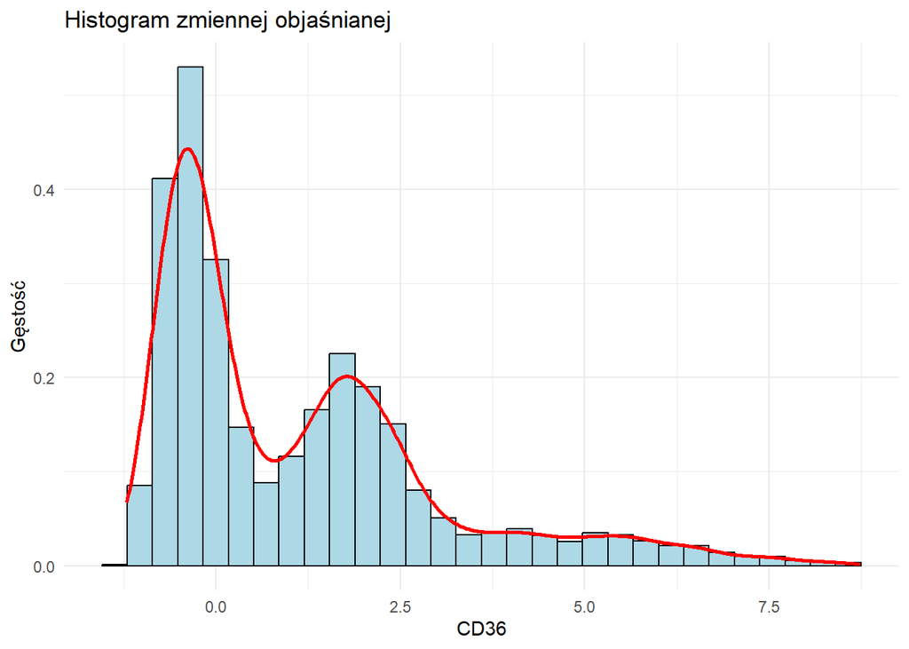

```r
# Histogram z gęstością
ggplot(Y_train, aes(x = CD36)) +
  geom_histogram(aes(y = ..density..),
                 bins = 30,
                 fill = "lightblue",
                 color = "black") +
  geom_density(color = "red", size = 1) +
  labs(title = "Histogram zmiennej objaśnianej",
       x = "CD36",
       y = "Gęstość") +
  theme_minimal()
```

Patrząc na rozkład empiryczny Y_train ciężko powiedzieć z jakiego rozkładu mógłby pochodzić. Przedstawmy podstawowe statystyki rozkładu, czyli między innymi max wartość, min wartość, średnią, medianę.

### Statystyki opisowe

```r
summary(Y_train)
```

```
##       CD36
##  Min.   :-1.2068
##  1st Qu.:-0.3675
##  Median : 0.4036
##  Mean   : 1.1066
##  3rd Qu.: 2.0484
##  Max.   : 8.7388
```

## 1.3 Analiza korelacji

Wybieramy 250 zmiennych objaśniających najbardziej skorelowanych z CD36 i obrazujemy korelacje na mapie cieplnej.

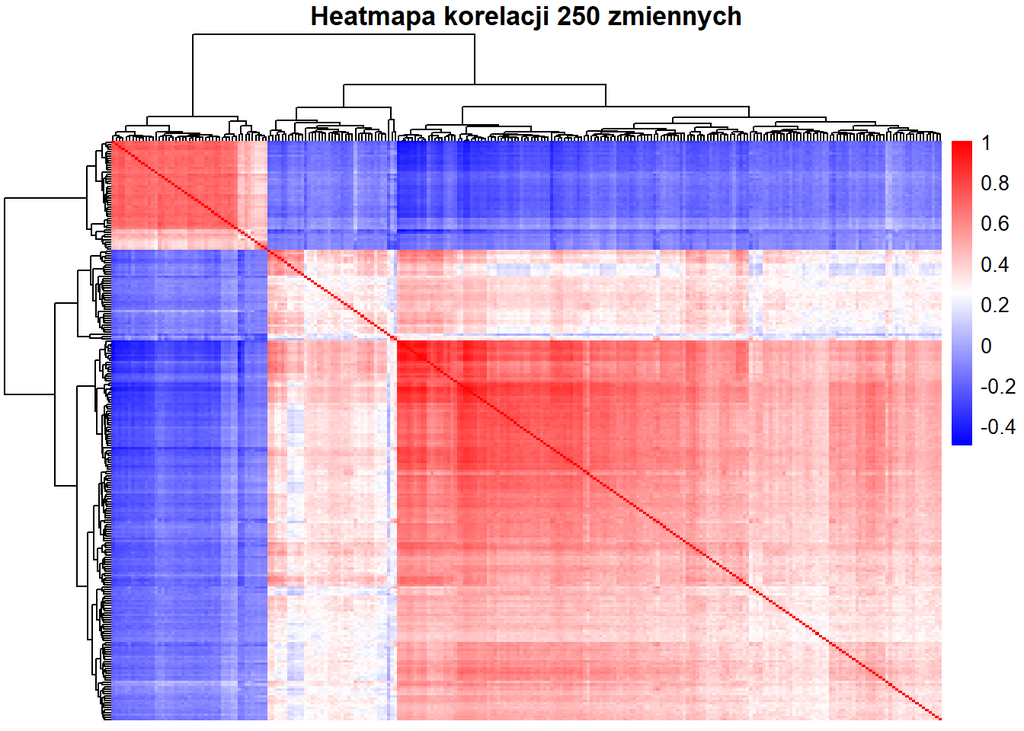

```r
# Korelacje z CD36
cors   <- cor(X_train, Y_train)
# 250 najlepszych
X_cor  <- X_train[, order(abs(cors), decreasing = TRUE)[1:250]]
cor_mat <- cor(X_cor)

# Heatmapa korelacji
pheatmap(
   cor_mat,
   color = colorRampPalette(c("blue", "white", "red"))(100),
   show_rownames = FALSE,
   show_colnames = FALSE,
   main = "Heatmapa korelacji 250 zmiennych")
```

Z mapy wynika, że niektóre zmienne są ze sobą mocno skorelowane.

# 2. Testy statystyczne

## 2.1 Wykres kwantylowy zmiennej objaśnianej

Przyjrzyjmy się wykresowi kwantylowemu (ang. QQ-plot), żeby porównać zmienną objaśnianą z rozkładem normalnym.

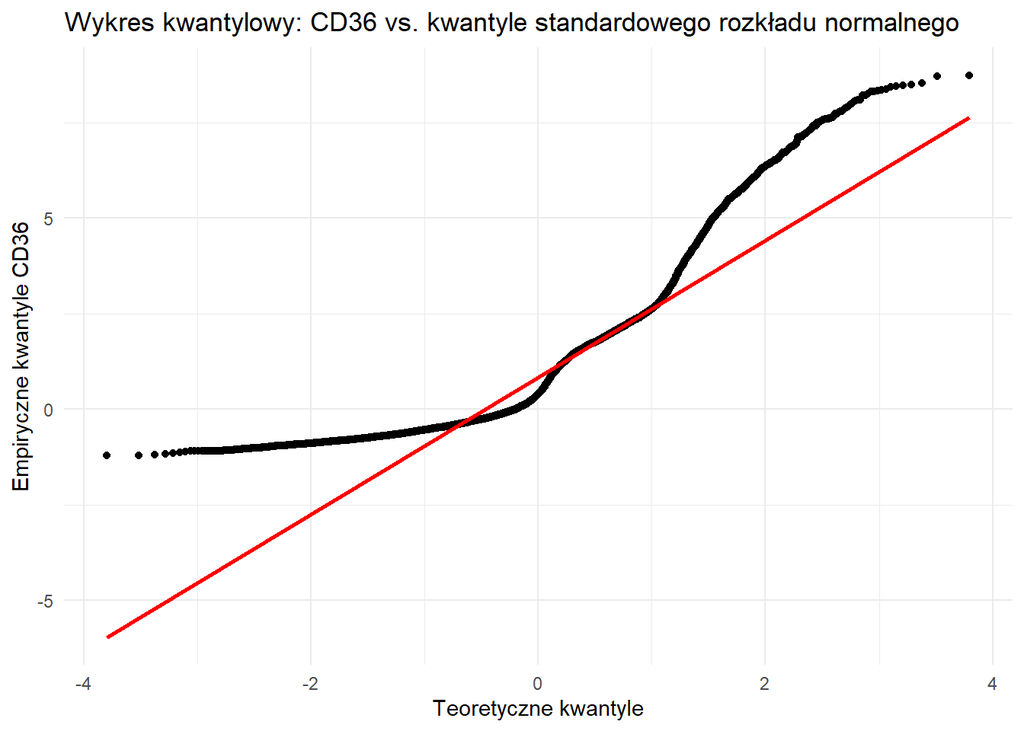

```r
ggplot(Y_train, aes(sample = CD36)) +
  geom_qq() +
  geom_qq_line(colour = "red", linewidth = 1) +
  labs(
    title = "Wykres kwantylowy: CD36 vs. kwantyle standardowego rozkładu normalnego",
    x = "Teoretyczne kwantyle",
    y = "Empiryczne kwantyle CD36"
  ) +
  theme_minimal()
```

Z wykresu trudno jest odczytać wartości średniej lub wariancji. Można jednak powiedzieć jak one się mają w stosunku do standardowego rozkładu normalnego. Z wykresu wynika, że średnia jest większa, ponieważ środek rozkładu Y_train jest przesunięty w prawo względem 0. Można zauważyć również, że odchylenie standardowe, które jest współczynnikiem nachylenia prostej na wykresie jest większe w przypadku rozkładu CD-36.

## 2.2 Testowanie zgodności z rozkładem normalnym

$H_1$: Rozkład nie pochodzi z rozkładu normalnego.

Ustalamy następujący poziom istotności : $\alpha = 0.05$

```r
#--- Test Shapiro-Wilka ---
set.seed(420)
shap_test <- shapiro.test(sample(Y_train$CD36, 5000))
print(shap_test)
```

```
##
##  Shapiro-Wilk normality test
##
## data:  sample(Y_train$CD36, 5000)
## W = 0.86138, p-value < 2.2e-16
```

```r
#--- Test Andersona-Darlinga --
ad_test <- ad.test(Y_train$CD36)
print(ad_test)
```

```
##
##  Anderson-Darling test of goodness-of-fit
##  Null hypothesis: uniform distribution
##  Parameters assumed to be fixed
##
## data:  Y_train$CD36
## An = Inf, p-value = 8.824e-08
```

## 2.3 Testowanie statystyczne dla wybranej zmiennej objaśniającej

Wybieramy najbardziej skorelowaną ze zmienną objaśnianą zmienną objaśniającą.

```r
cors <- cor(X_train,Y_train)
most_cor_name <- colnames(X_train)[which.max(cors)]
cat("Szukana zmienna z największym współczynnikiem korelacji ze zmienną objaśnianą to : ",most_cor_name, "\n")
```

```
## Szukana zmienna z największym współczynnikiem korelacji ze zmienną objaśnianą to :  BLVRB
```

Przedstawmy znalezioną zmienną na wykresie.

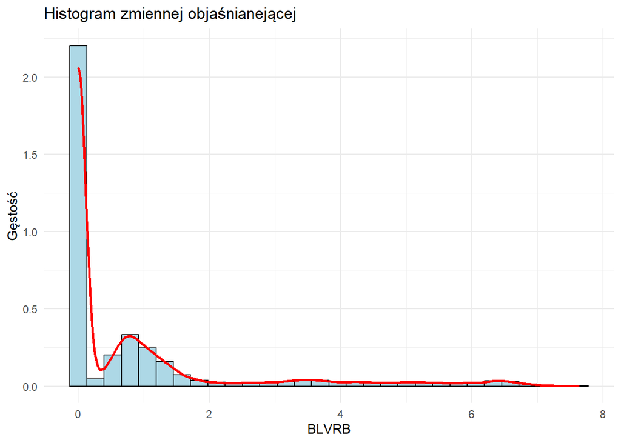

```r
# Histogram z gęstością
ggplot(X_train, aes(x = BLVRB)) +
  geom_histogram(aes(y = ..density..),
                 bins = 30,
                 fill = "lightblue",
                 color = "black") +
  geom_density(color = "red", size = 1) +
  labs(title = "Histogram zmiennej objaśnianejącej",
       x = "BLVRB",
       y = "Gęstość") +
  theme_minimal()
```

Na podstawie wykresu można wywnioskować, że są przesłanki do tego, żeby rozkład pochodził od rozkładu wykładniczego. Teraz musimy zastanowić się nad parametrem $\lambda$.

Spróbujmy wyestymować parametr $\lambda$. Użyjemy do tego estymatora największego prawdopodobieństwa. Po koniecznych obliczeniach otrzymujemy, że nasz estymator to $\hat\lambda_{MLE} = \frac{n}{\sum_{i=1}^{n} x_i}$. Więc w naszym przypadku:

```r
cat("Estymator lambda wynosi : ", 1/mean(X_train$BLVRB), "\n")
```

```
## Estymator lambda wynosi :  1.176306
```

Popatrzmy na wykres rozkładu empirycznego zmiennej objaśniającej i rozkładu wykładniczego.

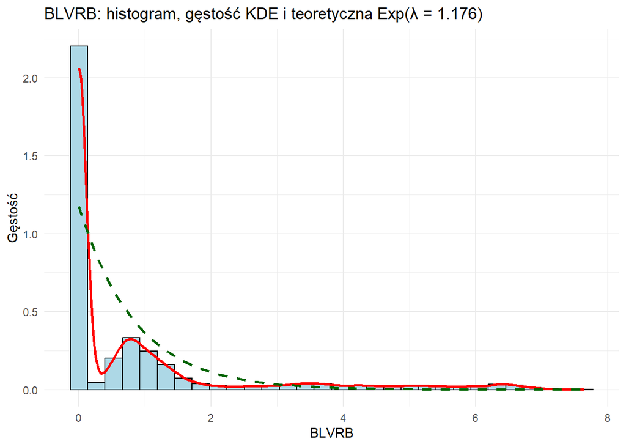

```r
lambda <- 1.176

ggplot(X_train, aes(x = BLVRB)) +
  geom_histogram(aes(y = ..density..),
                 bins  = 30,
                 fill  = "lightblue",
                 color = "black") +
  geom_density(color = "red", size = 1) +           # empiryczna KDE
  stat_function(fun  = dexp,                        # gęstość Exp(λ)
                args = list(rate = lambda),
                colour   = "darkgreen",
                linetype = "dashed",
                size     = 1) +
  labs(title = "BLVRB: histogram, gęstość KDE i teoretyczna Exp(λ = 1.176)",
       x = "BLVRB",
       y = "Gęstość") +
  theme_minimal()
```

Chcemy testować zgodność rozkładu empirycznego zmiennej objaśniającej i rozkładu wykładniczego. Użyjemy do tego testu Andersona-Darlinga tak jak w poprzednim przypadku. Test ten dobrze się sprawdza na dużych próbach. Skorzystamy z implementacji z biblioteki goftest, gdzie możemy zmieniać rozkłady, które porównujemy z danymi.

$H_0$: Rozkład zmiennej objaśniającej pochodzi z rozkładu wykładniczego $Exp(\lambda = 1,176)$.

$H_1$: Rozkład nie pochodzi z tego rozkładu.

Ustalamy następujący poziom istotności : $\alpha = 0.05$

```r
ad_test2 <- ad.test(X_train$BLVRB, null = "pexp", rate = lambda)
print(ad_test2)
```

```
##
##  Anderson-Darling test of goodness-of-fit
##  Null hypothesis: exponential distribution
##  with parameter rate = 1.176
##  Parameters assumed to be fixed
##
## data:  X_train$BLVRB
## An = Inf, p-value = 8.824e-08
```

Odrzucamy hipotezę zerową, więc rozkład BLVRB nie pochodzi z rozkładu wykładniczego.

Chcemy teraz testować, czy nasza zmienna ma podobny rozkład na zbiorze treningowym i testowym. Na początku popatrzmy na oba rozkłady.

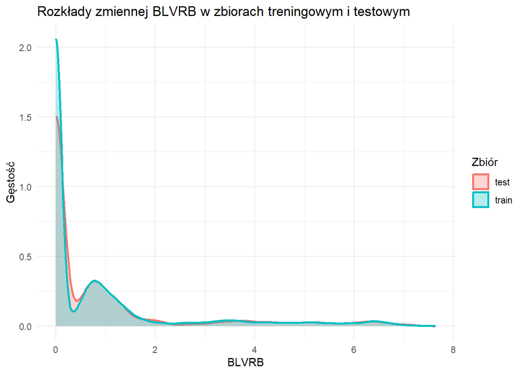

```r
data <- bind_rows(
  data.frame(BLVRB = X_train$BLVRB, set = "train"),
  data.frame(BLVRB = X_test$BLVRB,  set = "test")
)

ggplot(data, aes(x = BLVRB, fill = set, colour = set)) +
  geom_density(size = 1, alpha = 0.3) +
  labs(title = "Rozkłady zmiennej BLVRB w zbiorach treningowym i testowym",
       x = "BLVRB",
       y = "Gęstość",
       fill = "Zbiór",
       colour = "Zbiór") +
  theme_minimal()
```

Na pierwszy rzut oka rozkłady te są bardzo podobne. Przeprowadźmy test Wilcoxona, aby się upewnić. Test Wilcoxona porównuje mediany dwóch niezależnych grup, nie wymaga normalności, toleruje różne liczebności i dobrze się sprawdza dla rozkładów takich jak rozkład wykładniczy, a nasze rozkłady dany rozkład przypominają. Są to warunki, które spełnia zmienna BLVRB na zbiorach treningowym i testowym.

$H_0$: Rozkład zmiennej na dwóch zbiorach jest zlokalizowany tak samo.

$H_1$: Rozkład zmiennej nie jest zlokalizowany tak samo.

Ustalamy następujący poziom istotności : $\alpha = 0.05$

```r
wilc_test <- wilcox.test(X_train$BLVRB, X_test$BLVRB)
print(wilc_test)
```

```
##
##  Wilcoxon rank sum test with continuity correction
##
## data:  X_train$BLVRB and X_test$BLVRB
## W = 4081793, p-value = 0.9784
## alternative hypothesis: true location shift is not equal to 0
```

Duże p-value uniemożliwia nam odrzucenie hipotezy zerowej, więc możemy założyć że rozkłady są zlokalizowane tak samo.

# 3. ElasticNet

## 3.1 Opis modelu

Elastic Net (EN) to liniowy model regresyjny, który minimalizuje błąd średniokwadratowy wzbogacony o mieszankę dwóch kar regularizacyjnych:

- normy $\ell_2$ (tak jak w ridge),
- normy $\ell_1$ (tak jak w lasso).

Model więc działa tak jak klasyczne modele regresji, ale jego część regularyzacyjna to połączenie rozwiązań z Ridge Regression oraz Lasso Regression. Dzięki temu łączy stabilizację współczynników (ridge) z selekcją zmiennych (lasso). Model łączy zalety obu regresji.

Mamy dane postaci $(X_i,y_i)_{i=1}^{n}$, $X_i \in \mathbb R^p$, $y \in \mathbb R$. Optymalizowana funkcja celu modelu ma postać:

$$\mathcal L(\beta;\lambda,\alpha)=
\frac{1}{2n}\sum_{i=1}^{n}(y_i-X_i\beta)^2
\;+\;
\lambda\!\left[
(1-\alpha)\,\frac{\lVert\beta\rVert_2^{2}}{2}
\;+\;
\alpha\,\lVert\beta\rVert_1
\right].$$

,gdzie:

- $n, p$ - liczba obserwacji i liczba zmiennych
- $\beta=(\beta_1,\dots,\beta_p)^{\!\top}$ – współczynniki modelu
- $\lambda$ - hiperparametr kary
- $\alpha \in (0,1)$ - hiperparametr modelu ElasticNet, który będzie odpowiadał, która z dwóch regularyzacji będzie miała jaki wpływ na model
- $\lVert\beta\rVert_2^{2}=\sum_{j=1}^{p}\beta_j^{2}$
- $\lVert\beta\rVert_1 =\sum_{j=1}^{p}|\beta_j|$.

Będziemy szukali takich parametrów $\beta$, która minimalizuje tą funkcję.

Szczególne przypadki:

- $\alpha = 0$ : **Regresja grzbietowa (ridge)**

  $$\mathcal L_{\text{ridge}}
  =\frac{1}{2n}\lVert y-X\beta\rVert_2^{2}
  +\lambda\,\frac{\lVert\beta\rVert_2^{2}}{2}.$$
- $\alpha = 1$ :**Regresja Lasso**

  $$\mathcal L_{\text{lasso}}
  =\frac{1}{2n}\lVert y-X\beta\rVert_2^{2}
  +\lambda\,\lVert\beta\rVert_1.$$

## 3.2 Trenowanie modelu na różnych hiperparametrach

Poniższy kod tworzy najpierw tworzy foldy. Będę używal walidacji krzyżowej z 5 foldami z uwago na ograniczoną moc obliczeniową. Aby wynik był dokładny najlepiej byłoby użyć 10 foldów. Kod następnie tworzy siatkę hiperparametrów, gdzie $\alpha \in (0, 0.25, 0.5, 0.75, 1)$ oraz $\lambda \in (10, 1, 0.1, 0.01)$. Później w pętli trenujemy model po pierwsze na każdym foldzie, a po drugie z każdą kombinacją alf i lambd.

```r
X_mat <- as.matrix(X_train)
y_vec <- as.numeric(Y_train$CD36)

k <- 5
make_folds <- function(y, k = 5, seed = 420) {
  set.seed(seed)
  strata <- ifelse(y == 0, "zero", "nonzero")
  folds  <- integer(length(y))
  for (s in unique(strata)) {
    idx <- which(strata == s)
    folds[idx] <- sample(rep(seq_len(k), length.out = length(idx)))
  }
  folds
}
fold_id <- make_folds(y_vec, k)


alpha_grid  <- c(0, 0.25, 0.5, 0.75, 1)
lambda_grid <- 10 ^ seq(1, -2, length.out = 4)

cv_results   <- data.frame(alpha = numeric(),
                           lambda = numeric(),
                           mse    = numeric())
fold_results <- data.frame(alpha = numeric(),
                           lambda = numeric(),
                           fold  = integer(),
                           mse   = numeric())

for (a in alpha_grid) {
  for (l in lambda_grid) {

    mse_fold <- numeric(k)

    for (fold in seq_len(k)) {
      train_idx <- fold_id != fold
      test_idx  <- fold_id == fold

      mod <- glmnet(
        x      = X_mat[train_idx, , drop = FALSE],
        y      = y_vec[train_idx],
        alpha  = a,
        lambda = l,
        family = "gaussian"
      )
      pred <- predict(mod, s = l,
                      newx = X_mat[test_idx, , drop = FALSE])
      mse_fold[fold] <- mean((y_vec[test_idx] - pred)^2)
    }


    cv_results <- rbind(cv_results,
                        data.frame(alpha  = a,
                                   lambda = l,
                                   mse    = mean(mse_fold)))


    fold_results <- rbind(fold_results,
                          data.frame(alpha  = rep(a, k),
                                     lambda = rep(l, k),
                                     fold   = seq_len(k),
                                     mse    = mse_fold))

  }
}

best_row <- cv_results[which.min(cv_results$mse), ]
print(best_row)
```

```
##    alpha lambda       mse
## 20     1   0.01 0.1999863
```

Widzimy, że najlepszą parą hiperparametrów, gdzie błąd średniokwadratowy jest najmniejszy to $\alpha = 1, \lambda = 0.01$. Zauważmy, że najlepiej spisał się model LASSO, ponieważ $\alpha = 1$

## 3.3 Wykresy skrzypcowe błędów średniokwadratowych

Poniższe wykresy dzielą się na 5, dla każdego $\alpha$, a w każdym z nich są wykresy skrzypcowe dla każdego $\lambda$. Na wykresach zaznaczone są wartości MSE dla każdego foldu przez kropkę oraz średnią z nich przez krzyżyk.

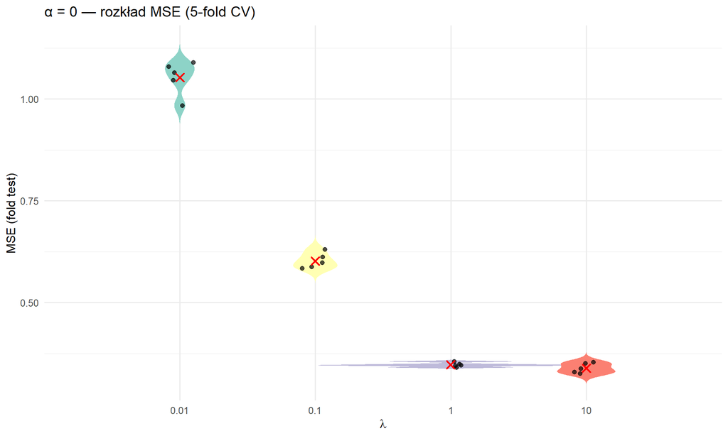

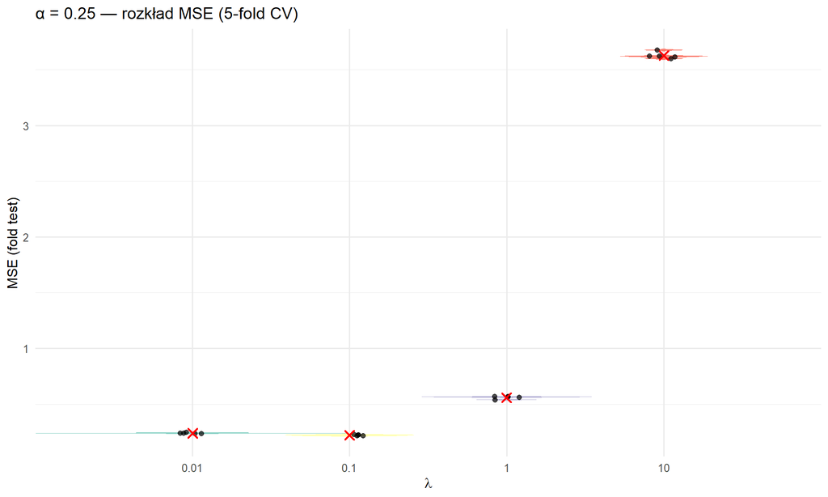

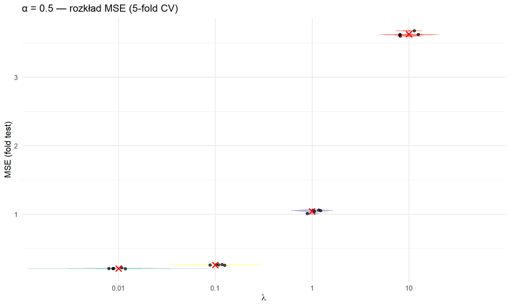

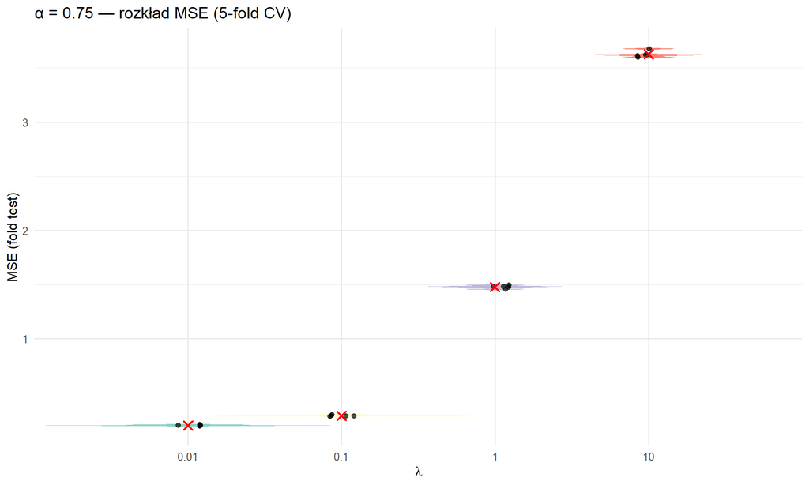

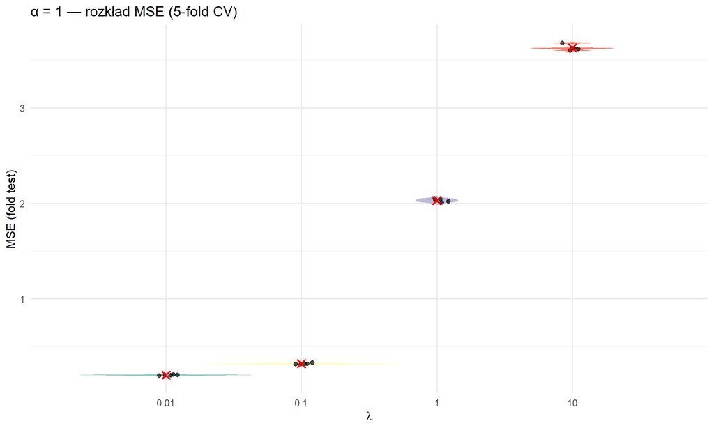

```r
fold_results <- fold_results %>%
  mutate(alpha_f  = factor(alpha),
         lambda_f = factor(signif(lambda, 2)))

unique_alphas <- levels(fold_results$alpha_f)
plots <- vector("list", length(unique_alphas))
names(plots) <- paste0("alpha_", unique_alphas)

for (i in seq_along(unique_alphas)) {
  a <- unique_alphas[i]
  data_subset <- filter(fold_results, alpha_f == a)

  p <- ggplot(data_subset, aes(x = lambda_f, y = mse, fill = lambda_f)) +
    geom_violin(trim = FALSE, alpha = 1, colour = NA, width = 2) +
    geom_point(position = position_jitter(width = 0.10, height = 0),
               size = 1.8, alpha = 0.7, colour = "black") +
    stat_summary(fun = mean, geom = "point",
                 shape = 4, size = 3, stroke = 1.1, colour = "red") +
    scale_fill_brewer(palette = "Set3", name = expression(lambda)) +
    labs(title = paste("α =", a, "— rozkład MSE (5-fold CV)"),
         x     = expression(lambda),
         y     = "MSE (fold test)") +
    theme_minimal(base_size = 12) +
    theme(
      legend.position = "none",
      axis.text.x     = element_text(angle = 0)
    )

  plots[[i]] <- p
}
for (pl in plots) print(pl)
```

## 3.3 Błąd dla najlepszych hiperparametrów

Policzmy błąd średniokwadratowy na zbiorze treningowym i walidacyjnym.

```r
alpha_best  <- best_row$alpha
lambda_best <- best_row$lambda

train_mse_en <- numeric(k)
val_mse_en   <- numeric(k)

for (fold in 1:k) {
  idx_tr <- fold_id != fold
  idx_te <- fold_id == fold

  fit <- glmnet(
    x      = X_mat[idx_tr, , drop = FALSE],
    y      = y_vec[idx_tr],
    alpha  = alpha_best,
    lambda = lambda_best,
    family = "gaussian"
  )


  pred_tr <- predict(fit, s = lambda_best,
                     newx = X_mat[idx_tr, , drop = FALSE])
  pred_te <- predict(fit, s = lambda_best,
                     newx = X_mat[idx_te, , drop = FALSE])

  train_mse_en[fold] <- mean((y_vec[idx_tr] - pred_tr)^2)
  val_mse_en  [fold] <- mean((y_vec[idx_te] - pred_te)^2)
}

avg_train_mse_en <- mean(train_mse_en)
avg_val_mse_en   <- mean(val_mse_en)

cat("Elastic Net  (α =", alpha_best, ", λ =", lambda_best, ")\n")
```

```
## Elastic Net  (α = 1 , λ = 0.01 )
```

```r
cat("Średni MSE  na zbiorze treningowym:", avg_train_mse_en, "\n")
```

```
## Średni MSE  na zbiorze treningowym: 0.1350669
```

```r
cat("Średni MSE  na danych walidacyjnych:", avg_val_mse_en, "\n")
```

```
## Średni MSE  na danych walidacyjnych: 0.1999863
```

Różnica rzędu kilkudziesięciu procent między wartościami sugeruje, że mogło pojawić się przeuczenie, czyli model nauczył się danych tylko na zbiorze treningowym.

# 4. Lasy Losowe

## 4.1 Trenowanie modelu na różnych hiperparametrach

Wytrenujemy teraz kilka modeli lasów losowych. Hiperparametry, które będziemy zmieniać to maksymalna głębokośc (max.depth), liczba drzew (n.trees) oraz maksymalna liczba zmiennych.

```r
X_df  <- as.data.frame(X_mat)
X_df$y <- y_vec

p <- ncol(X_mat)

grid_rf <- expand.grid(
  num.trees = c(50, 100, 150),
  mtry      = c(round(0.5*sqrt(p)),
                round(sqrt(p))),
  max.depth = c(5, 10, 15)
)


results_rf  <- data.frame()
fold_mse_rf <- data.frame()

for (i in seq_len(nrow(grid_rf))) {
  g <- grid_rf[i, ]
  mse_fold <- numeric(k)

  for (f in 1:k) {
    idx_tr <- fold_id != f
    idx_te <- fold_id == f

    fit <- ranger(
      y ~ .,
      data      = X_df[idx_tr, ],
      num.trees = g$num.trees,
      mtry      = g$mtry,
      max.depth = g$max.depth,
      min.node.size = 1,
      seed      = 420,
      respect.unordered.factors = "partition",
      verbose   = FALSE
    )

    pred <- predict(fit, data = X_df[idx_te, ])$predictions
    mse_fold[f] <- mean((y_vec[idx_te] - pred)^2)

    fold_mse_rf <- rbind(fold_mse_rf,
      data.frame(num.trees = g$num.trees,
                 mtry      = g$mtry,
                 max.depth = g$max.depth,
                 fold      = f,
                 mse       = mse_fold[f]))
  }

  results_rf <- rbind(results_rf,
      data.frame(g, mean_mse = mean(mse_fold)))
}

best_rf <- results_rf %>% arrange(mean_mse) %>% slice(1)
cat("Najlepsza konfiguracja: \n")
```

```
## Najlepsza konfiguracja:
```

```r
print(best_rf)
```

```
##   num.trees mtry max.depth mean_mse
## 1       150   95        15 0.297454
```

## 4.2 Wykresy pudełkowe wyników

Obrazujemy teraz MSE na 3 wykresach w zależności od głębokości. Na każdym wykresie znajduje się 6 box-plotów, które odpowiadają kombinacją hiperparametrów.

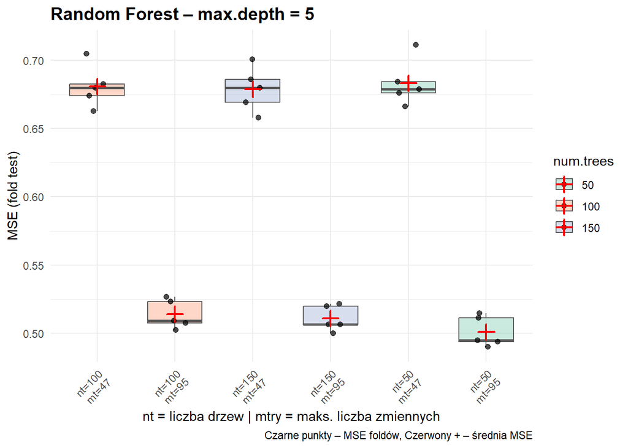

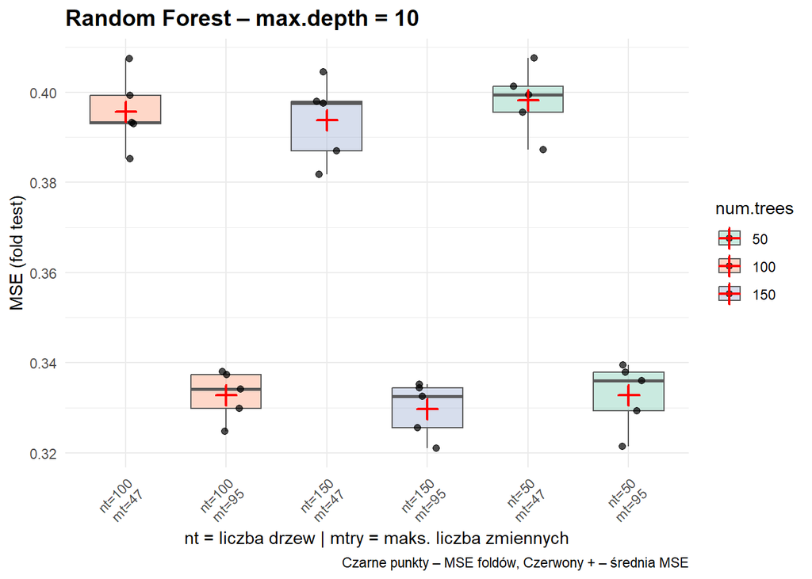

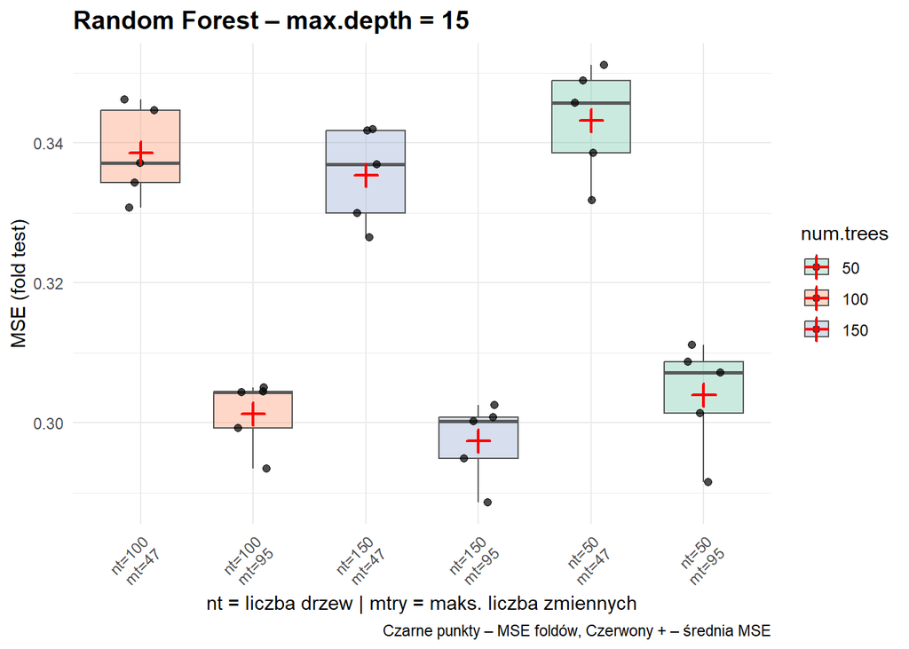

```r
fold_all <- fold_mse_rf %>%
  mutate(
    mtry_f = factor(mtry,  levels = sort(unique(mtry))),
    nt_f   = factor(num.trees, levels = c(50, 100, 150)),
    cfg    = paste0("nt=", nt_f, "\nmt=", mtry_f)
  )

depth_vals <- sort(unique(fold_all$max.depth))
for (d in depth_vals) {

  p <- fold_all %>% filter(max.depth == d) %>%
    ggplot(aes(x = cfg, y = mse, fill = nt_f)) +
      geom_boxplot(outlier.shape = NA, width = .7,
                   alpha = .35, colour = "grey35") +
      geom_point(position = position_jitter(width = .15, height = 0),
                 size = 1.8, alpha = .7, colour = "black") +
      scale_fill_brewer(palette = "Set2", name = "num.trees") +
      stat_summary(fun = mean, geom = "point",
                   shape = 3, size = 3.5, stroke = 1.1, colour = "red") +
      labs(title = paste("Random Forest – max.depth =", d),
           x     = "nt = liczba drzew | mtry = maks. liczba zmiennych",
           y     = "MSE (fold test)",
           caption = "Czarne punkty – MSE foldów, Czerwony + – średnia MSE") +
      theme_minimal() +
      theme(
        axis.text.x = element_text(angle = 45, hjust = 1),
        plot.title  = element_text(size = 14, face = "bold")
      )

  print(p)
}
```

## 4.3 Błąd dla najlepszych hiperparametrów

Teraz bierzemy najlepsze hiperparametry i trenujemy model, żeby otrzymać błąd na zbiorze walidacyjnym i treningowym.

```r
nt_best  <- best_rf$num.trees
mtry_best<- best_rf$mtry
depth_best <- best_rf$max.depth

train_mse <- numeric(k)
val_mse   <- numeric(k)

for (f in 1:k) {
  idx_tr <- fold_id != f
  idx_te <- fold_id == f

  fit <- ranger(
    y ~ .,
    data            = X_df[idx_tr, ],
    num.trees       = nt_best,
    mtry            = mtry_best,
    max.depth       = depth_best,
    min.node.size   = 1,
    seed            = 420,
    respect.unordered.factors = "partition",
    verbose         = FALSE
  )

  pred_tr <- predict(fit, data = X_df[idx_tr, ])$predictions
  pred_te <- predict(fit, data = X_df[idx_te, ])$predictions

  train_mse[f] <- mean((X_df$y[idx_tr] - pred_tr)^2)
  val_mse[f]   <- mean((X_df$y[idx_te] - pred_te)^2)
}

avg_train <- mean(train_mse)
avg_val   <- mean(val_mse)

cat("Random Forest  (nt =", nt_best,
    ",  mtry =", mtry_best,
    ",  max.depth =", depth_best, ")\n")
```

```
## Random Forest  (nt = 150 ,  mtry = 95 ,  max.depth = 15 )
```

```r
cat("Średni MSE zbiór treningowy :", avg_train, "\n")
```

```
## Średni MSE zbiór treningowy : 0.09102514
```

```r
cat("Średni MSE zbiór walidacyjny :", avg_val, "\n")
```

```
## Średni MSE zbiór walidacyjny : 0.297454
```

Tutaj również możemy zauwaćyć, że model slabo generalizuje.

# 5. Podsumowanie

Zacznijmy od modelu referencyjnego, który zmiennyym objaśniającym w foldzie testowym przypisuje średnią arytmetyczną zmiennej objaśnianej policzoną w foldach treningowych.

```r
mse_ref_val <- numeric(length(k))   # tu zbierzemy błędy walidacyjne
mse_ref_tr   <- numeric(length(k))   # i treningowe (opcjonalnie)

for (i in 1:k) {
  idx_tr <- fold_id != i
  idx_te <- fold_id == i

  y_bar  <- mean(y_vec[idx_tr])

  mse_ref_tr[i] <- mean( (y_vec[idx_tr] - y_bar)^2 )
  mse_ref_val[i] <- mean( (y_vec[idx_te] - y_bar)^2 )
}

#  ramka z wynikami per-fold  (łatwa do rbind z innymi modelami)
ref_results_df <- data.frame(
  Fold            = seq_along(1:k),
  Ref_MSE_Train   = mse_ref_tr,
  Ref_MSE_Val     = mse_ref_val
)

#  średnie – do szybkiego podglądu
avg_train_ref <- mean(mse_ref_tr)
avg_val_ref   <- mean(mse_ref_val)

cat("Średni MSE na zbiorze treningowym model referencyjny :", round(avg_train_ref, 5), "\n")
```

```
## Średni MSE na zbiorze treningowym model referencyjny : 3.62655
```

```r
cat("Średni MSE na zbiorze walidacyjnym model referencyjny :", round(avg_val_ref,   5), "\n")
```

```
## Średni MSE na zbiorze walidacyjnym model referencyjny : 3.62692
```

Aby podsumować wyniki wypisujemy poniższą tabele.

```r
train_mse_rf <- train_mse
val_mse_rf   <- val_mse

mse_tbl <- data.frame(
  Fold           = 1:k,
  EN_Train_MSE   = round(train_mse_en, 5),
  EN_Val_MSE     = round(val_mse_en,   5),
  RF_Train_MSE   = round(train_mse_rf, 5),
  RF_Val_MSE     = round(val_mse_rf,   5),
  REF_Train_MSE  = round(mse_ref_tr,   5),
  REF_Val_MSE    = round(mse_ref_val,  5)
)

avg_row <- data.frame(
  Fold           = "AVG",
  EN_Train_MSE   = round(mean(train_mse_en), 5),
  EN_Val_MSE     = round(mean(val_mse_en),   5),
  RF_Train_MSE   = round(mean(train_mse_rf), 5),
  RF_Val_MSE     = round(mean(val_mse_rf),   5),
  REF_Train_MSE  = round(mean(mse_ref_tr),   5),
  REF_Val_MSE    = round(mean(mse_ref_val),  5)
)

mse_tbl <- rbind(mse_tbl, avg_row)

print(mse_tbl)
```

```
##   Fold EN_Train_MSE EN_Val_MSE RF_Train_MSE RF_Val_MSE REF_Train_MSE
## 1    1      0.13567    0.20059      0.09186    0.28867       3.61412
## 2    2      0.13388    0.20554      0.08967    0.30020       3.62738
## 3    3      0.13552    0.19340      0.09359    0.30086       3.62804
## 4    4      0.13503    0.19773      0.09032    0.29494       3.63347
## 5    5      0.13523    0.20267      0.08969    0.30258       3.62976
## 6  AVG      0.13507    0.19999      0.09103    0.29745       3.62655
##   REF_Val_MSE
## 1     3.67647
## 2     3.62350
## 3     3.62121
## 4     3.59915
## 5     3.61425
## 6     3.62692
```

Podsumowując wyniki najlepsze uzyskał model ElasticNet. Model ten jest również bardziej wytłumaczlany niż lasy losowe i równiez szybszy.

Uważam, że wyniki można było uzyskać lepsze i dokładniejsze. Dokładniejsze, dlatego że powinniśmy użyć 10 foldów co jest często stosowaną liczbą. Lepsze przez dokładniejszy tuning hiperparametrów. Już na ten moment, gdy gridy hiperparametrów w podpunkcie 3 i 4 były stosunkowo małe czas obliczeniowy na ograniczonym sprzęcie wyniósł bardzo długo (Ciekawostka: plik html bez rozdziału 5 renderował się 57 minut). Jeśli poszerzylibyśmy siatki myślę, że uzyskalibyśmy lepsze wyniki.